# Part II - (Bike Sharing Analysis with Ford GoBike Data)

## by (Mubarak Hamza)

## Investigation Overview

> Key Insights For the presentation, I focus on the influence of Trip duration, Rides per Gender,user type group of bike hiring data. I start by sharing a plot for the average trip duration which turns out to be 10 minutes, followed by a plot for gender type rides, which clerly shoes that Males has the most rides. Then a plot of user type sharing, figuring out which user type either subsribers or customers have a large share of the bike trips. I tried to use different color palettes for each variables to make sure it is clear

## Dataset Overview

> Ford GoBike is a regional public bicycle sharing system in the San Francisco Bay Area, California. Beginning operation in August 2013 as Bay Area Bike Share, the Ford GoBike system currently has over 2,600 bicycles in 262 stations across San Francisco, East Bay and San Jose. On June 28, 2017, the system officially launched as Ford GoBike in a partnership with Ford Motor Company. Ford GoBike, like other bike share systems, consists of a fleet of specially designed, sturdy and durable bikes that are locked into a network of docking stations throughout the city. The bikes can be unlocked from one station and returned to any other station in the system, making them ideal for one-way trips. The bikes are available for use 24 hours/day, 7 days/week, 365 days/year and riders have access to all bikes in the network when they become a member or purchase a pass.

## (Visualization 1)

## Average Trip Duration

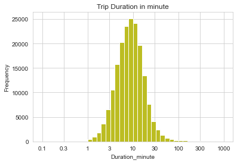

## (Visualization 2)

## Bike Rides Per Gender

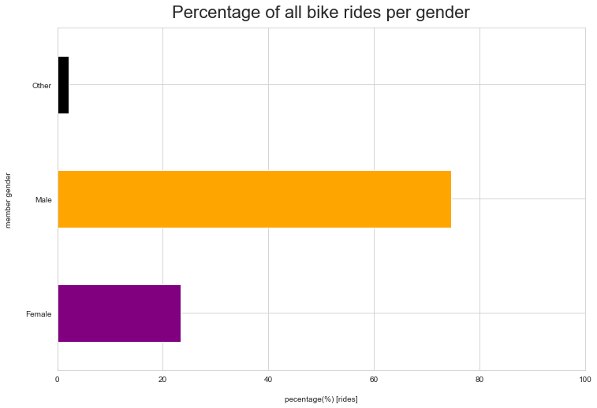

## (Visualization 3)

## User Type Percentage Split

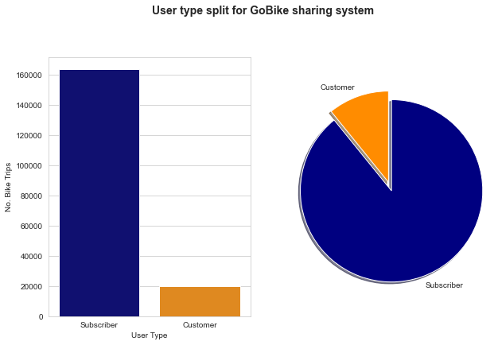